# GLMMs

vmbolea

2025-12-16

# Data

```r
print(data_, n = 90)
```

```
## # A tibble: 88 × 8
##    ID       sex   repro_status context month n_leader n_front n_back
##    <chr>    <chr> <chr>        <chr>   <dbl>    <dbl>   <int>  <int>
##  1 ABU      F     AFC          Defense     9        0       8      4
##  2 ABU      F     AFC          Feeding     9        1       3     12
##  3 ABU      F     AFC          Defense    10        0       2      1
##  4 ABU      F     AFC          Feeding    10        0       1      5
##  5 ALHAMBRA F     AFL          Defense     7        1      12      6
##  6 ALHAMBRA F     AFL          Feeding     7       10      19     11
##  7 ALHAMBRA F     AFL          Defense     8        2       2      2
##  8 ALHAMBRA F     AFL          Feeding     8        3      10      5
##  9 BUBBLE   F     AFC          Defense     7        1       6     12
## 10 BUBBLE   F     AFC          Feeding     7        1      10     29
## 11 BUBBLE   F     AFC          Defense     8        0       2      4
## 12 BUBBLE   F     AFC          Feeding     8        0       3     15
```

[output cut: 76 more lines]

# TUTOR: Linear mixed models(GLMM)

To investigate the factors influencing leadership probability, we fitted Generalized Linear Mixed Models (GLMMs) with a binomial error distribution and a logit link function, utilizing the lme4 package.

We constructed the response variable as a two-column matrix binding the number of times an individual acted as a leader versus the number of times they acted as a follower. We ran separate models for each of the two leadership contexts defined previously:

- 1. movements toward feeding trees and defense-related movements. To test our predictions regarding sex differences, we included sex as the fixed effect in the models for both contexts.
- 2. to evaluate the influence of female reproductive state, we analyzed a subset of the data containing only female subjects, with reproductive status (cycling, lactating, or with dependents) serving as the fixed predictor.

In all models, we included subject identity as a random intercept to control for repeated measures and potential pseudo-replication arising from sampling the same individuals multiple times. We determined the statistical significance of the fixed effects by performing Likelihood Ratio Tests (LRT), comparing the full models against null models that included only the random intercept, setting the significance threshold at p < .05.

Data table is prepared for the next analysis aggregating data per month and creating a single column of number of times as follower and the proportion of times that each individual is leader per the total number of movements in each context.

```r
print(dat, n = 90)
```

```
## # A tibble: 44 × 7
##    ID       sex   repro_status context n_leader n_follower   prop
##    <chr>    <chr> <chr>        <chr>      <dbl>      <int>  <dbl>
##  1 ABU      F     AFC          Defense        0         15 0
##  2 ABU      F     AFC          Feeding        1         21 0.0455
##  3 ALHAMBRA F     AFL          Defense        3         22 0.12
##  4 ALHAMBRA F     AFL          Feeding       13         45 0.224
##  5 BUBBLE   F     AFC          Defense        1         24 0.04
##  6 BUBBLE   F     AFC          Feeding        1         57 0.0172
##  7 BUENA    F     AFD          Defense        0         15 0
##  8 BUENA    F     AFD          Feeding        6         15 0.286
##  9 BUENO    M     M            Defense        7          8 0.467
## 10 BUENO    M     M            Feeding        4         17 0.190
## 11 CHINA    F     AFL          Defense        0         25 0
## 12 CHINA    F     AFL          Feeding        5         52 0.0877
```

[output cut: 32 more lines]

## GLMM for sex and context

### Feeding movement

```
## Data: feed
## Models:
## m_feed_null: cbind(n_leader, n_follower) ~ 1 + (1 | ID)
## m_feed_full: cbind(n_leader, n_follower) ~ sex + (1 | ID)
##             npar    AIC    BIC  logLik -2*log(L) Chisq Df Pr(>Chisq)
## m_feed_null    2 100.17 102.35 -48.083    96.167
## m_feed_full    3 101.36 104.64 -47.682    95.364 0.803  1     0.3702
```

Key points

- Leadership during feeding is generally low, and sex does not have a detectable effect in this dataset.
- Random intercept (1 | ID) accounts for individual differences.
- AIC/BIC slightly increase for the full model → confirms that sex does not improve model fit.

```r
summary(m_feed_full)
```

```
## Generalized linear mixed model fit by maximum likelihood (Laplace
##   Approximation) [glmerMod]
##  Family: binomial  ( logit )
## Formula: cbind(n_leader, n_follower) ~ sex + (1 | ID)
##    Data: feed
##
##       AIC       BIC    logLik -2*log(L)  df.resid
##     101.4     104.6     -47.7      95.4        19
##
## Scaled residuals:
##      Min       1Q   Median       3Q      Max
## -1.03525 -0.48742 -0.09669  0.35047  1.35088
##
## Random effects:
##  Groups Name        Variance Std.Dev.
##  ID     (Intercept) 0.4211   0.6489
## Number of obs: 22, groups:  ID, 22
##
## Fixed effects:
##             Estimate Std. Error z value Pr(>|z|)
## (Intercept)  -2.5459     0.2516 -10.118   <2e-16 ***
## sexM          0.3955     0.4515   0.876    0.381
## ---
## Signif. codes:  0 '***' 0.001 '**' 0.01 '*' 0.05 '.' 0.1 ' ' 1
##
## Correlation of Fixed Effects:
##      (Intr)
## sexM -0.558
```

Conclusion:

- Leadership probability during feeding is low (~7–10%).
- Sex does not significantly influence leadership during feeding.
- Random intercept accounts for individual differences.

### Defence movement

```
## Data: defense
## Models:
## m_def_null: cbind(n_leader, n_follower) ~ 1 + (1 | ID)
## m_def_full: cbind(n_leader, n_follower) ~ sex + (1 | ID)
##            npar    AIC    BIC  logLik -2*log(L)  Chisq Df Pr(>Chisq)
## m_def_null    2 82.624 84.806 -39.312    78.624
## m_def_full    3 69.967 73.240 -31.983    63.967 14.657  1  0.0001289 ***
## ---
## Signif. codes:  0 '***' 0.001 '**' 0.01 '*' 0.05 '.' 0.1 ' ' 1
```

Key points:

- Males are much more likely to be leaders in defense than females.
- Random intercept accounts for individual differences.
- The large drop in AIC (82.6 → 69.97) further supports the strong effect of sex.

```r
summary(m_def_full)
```

```
## Generalized linear mixed model fit by maximum likelihood (Laplace
##   Approximation) [glmerMod]
##  Family: binomial  ( logit )
## Formula: cbind(n_leader, n_follower) ~ sex + (1 | ID)
##    Data: defense
##
##       AIC       BIC    logLik -2*log(L)  df.resid
##      70.0      73.2     -32.0      64.0        19
##
## Scaled residuals:
##     Min      1Q  Median      3Q     Max
## -0.9446 -0.6792 -0.2807  0.5094  1.2441
##
## Random effects:
##  Groups Name        Variance Std.Dev.
##  ID     (Intercept) 0.3835   0.6193
## Number of obs: 22, groups:  ID, 22
##
## Fixed effects:
##             Estimate Std. Error z value Pr(>|z|)
## (Intercept)  -3.3099     0.3648  -9.073  < 2e-16 ***
## sexM          2.1918     0.5085   4.310 1.63e-05 ***
## ---
## Signif. codes:  0 '***' 0.001 '**' 0.01 '*' 0.05 '.' 0.1 ' ' 1
##
## Correlation of Fixed Effects:
##      (Intr)
## sexM -0.695
```

Conclusion

### Boxplot

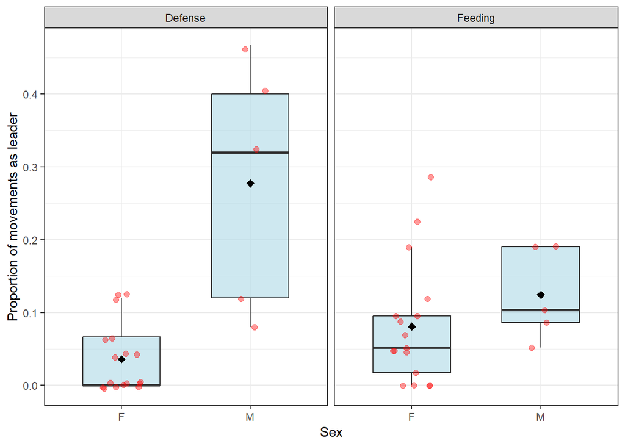

```r
ggplot(dat, aes(x = sex, y = prop, fill = sex)) +
  geom_boxplot(width = 0.6, alpha = 0.6, outlier.shape = NA) +
  geom_jitter(width = 0.15, alpha = 0.4, color = "red", size = 2) +
  stat_summary(fun = mean, geom = "point", shape = 23, size = 2, fill = "black") +
  facet_wrap(~context) +
  theme_bw() +
  labs(
    x = "Sex",
    y = "Proportion of movements as leader"
  ) +
  scale_fill_manual(values = c("F" = "lightblue", "M" = "lightblue")) +
  theme(legend.position = "none")
```

## GLMM for females with reproduction status and context

### Feeding movement

```
## Data: females %>% filter(context == "Feeding")
## Models:
## f_feed_null: cbind(n_leader, n_follower) ~ 1 + (1 | ID)
## f_feed_full: cbind(n_leader, n_follower) ~ repro_status + (1 | ID)
##             npar    AIC    BIC  logLik -2*log(L)  Chisq Df Pr(>Chisq)
## f_feed_null    2 76.071 77.738 -36.036    72.071
## f_feed_full    4 71.066 74.399 -31.533    63.066 9.0052  2    0.01108 *
## ---
## Signif. codes:  0 '***' 0.001 '**' 0.01 '*' 0.05 '.' 0.1 ' ' 1
```

Key points

- Leadership probability in female feeding movements depends on reproductive status.
- Random intercept (1 | ID) accounts for individual variation.
- Effect is statistically significant (p < 0.05), suggesting biological relevance.

```r
summary(f_feed_full)
```

```
## Generalized linear mixed model fit by maximum likelihood (Laplace
##   Approximation) [glmerMod]
##  Family: binomial  ( logit )
## Formula: cbind(n_leader, n_follower) ~ repro_status + (1 | ID)
##    Data: females %>% filter(context == "Feeding")
##
##       AIC       BIC    logLik -2*log(L)  df.resid
##      71.1      74.4     -31.5      63.1        13
##
## Scaled residuals:
##     Min      1Q  Median      3Q     Max
## -1.2730 -0.7093 -0.2283  0.4764  1.4746
##
## Random effects:
##  Groups Name        Variance Std.Dev.
##  ID     (Intercept) 0.2358   0.4856
## Number of obs: 17, groups:  ID, 17
##
## Fixed effects:
##                 Estimate Std. Error z value Pr(>|z|)
## (Intercept)      -3.5669     0.4589  -7.772 7.72e-15 ***
## repro_statusAFD   1.3598     0.6694   2.031  0.04221 *
## repro_statusAFL   1.5626     0.5145   3.037  0.00239 **
## ---
## Signif. codes:  0 '***' 0.001 '**' 0.01 '*' 0.05 '.' 0.1 ' ' 1
##
## Correlation of Fixed Effects:
##             (Intr) rp_AFD
## rpr_sttsAFD -0.636
## rpr_sttsAFL -0.861  0.568
```

Conclusion:

- Baseline female leaders (reference status) rarely lead (~3%).
- AFD and AFL females lead more often (~9–10%), significant increases.
- Individual variation is moderate (random intercept).
- Effect of reproductive status is statistically significant, meaning leadership during feeding depends on reproductive condition.

### Defence movement

```
## Data: females %>% filter(context == "Defense")
## Models:
## f_def_null: cbind(n_leader, n_follower) ~ 1 + (1 | ID)
## f_def_full: cbind(n_leader, n_follower) ~ repro_status + (1 | ID)
##            npar    AIC    BIC  logLik -2*log(L)  Chisq Df Pr(>Chisq)
## f_def_null    2 42.575 44.241 -19.288    38.575
## f_def_full    4 40.912 44.245 -16.456    32.912 5.6631  2    0.05892 .
## ---
## Signif. codes:  0 '***' 0.001 '**' 0.01 '*' 0.05 '.' 0.1 ' ' 1
```

Key points:

- Leadership probability among females during defense may depend on reproductive status, but the evidence is weak.
- Random intercept (1 | ID) accounts for individual differences.
- Effect is not statistically significant at the conventional 0.05 level, but it’s close (trend).

```r
summary(f_def_full)
```

```
## Generalized linear mixed model fit by maximum likelihood (Laplace
##   Approximation) [glmerMod]
##  Family: binomial  ( logit )
## Formula: cbind(n_leader, n_follower) ~ repro_status + (1 | ID)
##    Data: females %>% filter(context == "Defense")
##
##       AIC       BIC    logLik -2*log(L)  df.resid
##      40.9      44.2     -16.5      32.9        13
##
## Scaled residuals:
##     Min      1Q  Median      3Q     Max
## -1.3819 -0.5839 -0.4939  0.9548  1.1678
##
## Random effects:
##  Groups Name        Variance Std.Dev.
##  ID     (Intercept) 0        0
## Number of obs: 17, groups:  ID, 17
##
## Fixed effects:
##                 Estimate Std. Error z value Pr(>|z|)
## (Intercept)      -4.1190     0.7128  -5.778 7.54e-09 ***
## repro_statusAFD   0.3348     1.2373   0.271   0.7867
## repro_statusAFL   1.5471     0.7784   1.987   0.0469 *
## ---
## Signif. codes:  0 '***' 0.001 '**' 0.01 '*' 0.05 '.' 0.1 ' ' 1
##
## Correlation of Fixed Effects:
##             (Intr) rp_AFD
## rpr_sttsAFD -0.576
## rpr_sttsAFL -0.916  0.528
## optimizer (Nelder_Mead) convergence code: 0 (OK)
## boundary (singular) fit: see help('isSingular')
```

Conclusion:

### Boxplot

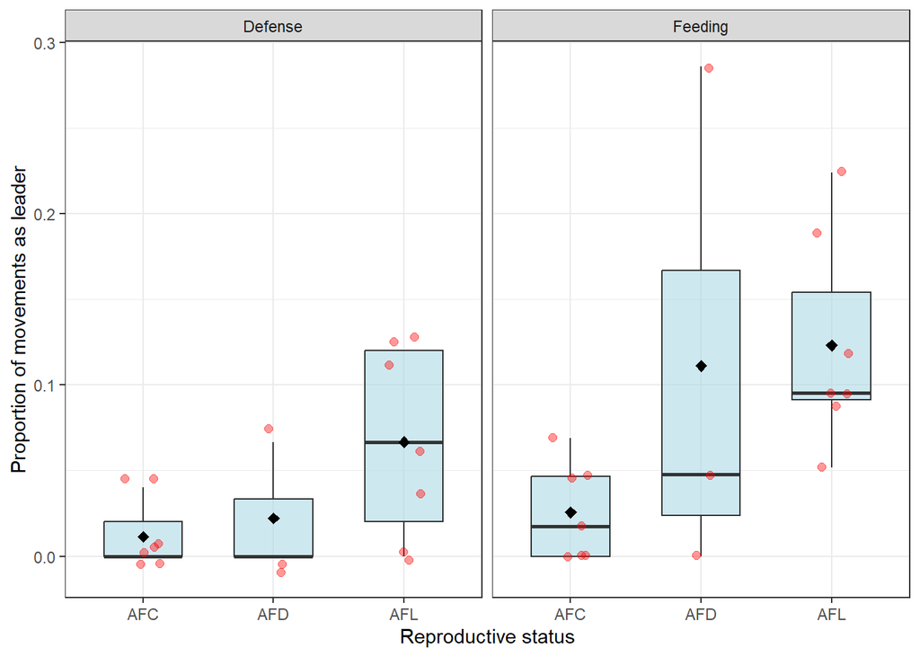

```r
ggplot(females, aes(x = repro_status, y = prop, fill = repro_status)) +
  geom_boxplot(width = 0.6, alpha = 0.6, outlier.shape = NA) +
  geom_jitter(width = 0.15, alpha = 0.4, color = "red", size = 2) +
  stat_summary(fun = mean, geom = "point", shape = 23, size = 2, fill = "black") +
  facet_wrap(~context) +
  theme_bw() +
  labs(x = "Reproductive status", y = "Proportion of movements as leader") +
  scale_fill_manual(values = c("AFC" = "lightblue", "AFD" = "lightblue", "AFL" = "lightblue"))+
  theme(legend.position = "none")
```

# PAPER: GLMM with binomial error distributions.

```r
print(df, n = 90)
```

```
## # A tibble: 88 × 13
## # Groups:   context, month [8]
##    ID       sex   repro_status context month n_leader n_front n_back n_follower
##    <fct>    <fct> <fct>        <chr>   <dbl>    <dbl>   <int>  <int>      <int>
##  1 ABU      F     AFC          Defense     9        0       8      4         12
##  2 ABU      F     AFC          Feeding     9        1       3     12         15
##  3 ABU      F     AFC          Defense    10        0       2      1          3
##  4 ABU      F     AFC          Feeding    10        0       1      5          6
##  5 ALHAMBRA F     AFL          Defense     7        1      12      6         18
##  6 ALHAMBRA F     AFL          Feeding     7       10      19     11         30
##  7 ALHAMBRA F     AFL          Defense     8        2       2      2          4
##  8 ALHAMBRA F     AFL          Feeding     8        3      10      5         15
##  9 BUBBLE   F     AFC          Defense     7        1       6     12         18
## 10 BUBBLE   F     AFC          Feeding     7        1      10     29         39
## 11 BUBBLE   F     AFC          Defense     8        0       2      4          6
```

[output cut: 79 more lines]

### First prediction with 2 models sex in feeding context

- first, the number of times each individual moved toward a feeding tree as a leader and as a follower per month was added as a two‐vector response variable and the fixed predictor was sex.

```r
run_model_leader_prop(df, response_type="leader_follower", predictor="sex", context_name="Feeding")
```

```
##
## Running models for context: Feeding and predictor: sex
## Data: dat
## Models:
## null1: cbind(n_leader, n_follower) ~ (1 | ID)
## model1: cbind(n_leader, n_follower) ~ sex + (1 | ID)
##        npar    AIC    BIC  logLik -2*log(L) Chisq Df Pr(>Chisq)
## null1     2 146.74 150.30 -71.368    142.74
## model1    3 147.93 153.28 -70.966    141.93 0.803  1     0.3702
```

```
## $model1
## Generalized linear mixed model fit by maximum likelihood (Laplace
##   Approximation) [glmerMod]
##  Family: binomial  ( logit )
## Formula: cbind(n_leader, n_follower) ~ sex + (1 | ID)
##    Data: dat
##
##       AIC       BIC    logLik -2*log(L)  df.resid
##     147.9     153.3     -71.0     141.9        41
##
## Scaled residuals:
##     Min      1Q  Median      3Q     Max
## -1.7318 -0.7291 -0.2161  0.7329  1.6493
##
## Random effects:
##  Groups Name        Variance Std.Dev.
##  ID     (Intercept) 0.4211   0.6489
## Number of obs: 44, groups:  ID, 22
##
## Fixed effects:
##             Estimate Std. Error z value Pr(>|z|)
## (Intercept)  -2.5459     0.2516 -10.118   <2e-16 ***
## sexM          0.3955     0.4515   0.876    0.381
## ---
## Signif. codes:  0 '***' 0.001 '**' 0.01 '*' 0.05 '.' 0.1 ' ' 1
##
## Correlation of Fixed Effects:
##      (Intr)
## sexM -0.558
```

Conclusion:

During Feeding, sex does not significantly influence the probability of leading versus following.

Individual variability: there is variation between IDs, reflected in the random effect.

Effect size: males may lead more, but with the current sample there is not enough statistical evidence to support this.

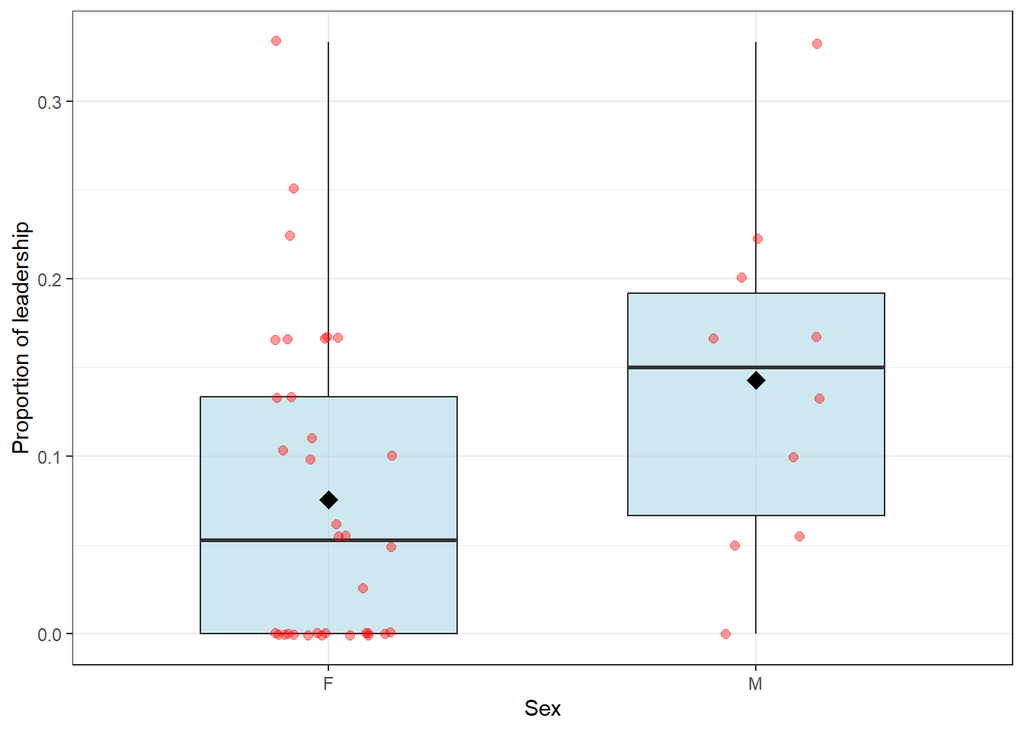

```r
# Filtramos solo el contexto Feeding
df_feeding <- subset(df, context == "Feeding")

# Boxplot
ggplot(df_feeding, aes(x = sex, y = prop_leader, fill = sex)) +
  geom_boxplot(width = 0.6, alpha = 0.6) +
  geom_jitter(width = 0.15, alpha = 0.4, color = "red", size = 2) +
  stat_summary(fun = mean, geom = "point", shape = 23, size = 3, fill = "black") +
  theme_bw() +
  labs(x = "Sex", y = "Proportion of leadership") +
  scale_fill_manual(values = c("F" = "lightblue", "M" = "lightblue"))+
  theme(legend.position = "none")
```

- second, the mean individual monthly progression order index during movements toward feeding trees categorized as “front” or “back” was the dependent variable and sex was the fixed predictor.

```r
run_model_order_index(df, response_type="order_index", predictor="sex", context_name="Feeding")
```

```
##
## Running models for context: Feeding and predictor: sex
```

```
## Data: dat
## Models:
## null2: prop_front ~ (1 | ID)
## model2: prop_front ~ sex + (1 | ID)
##        npar      AIC    BIC logLik -2*log(L)  Chisq Df Pr(>Chisq)
## null2     3 -2.50763 2.8449 4.2538   -8.5076
## model2    4 -0.99155 6.1452 4.4958   -8.9916 0.4839  1     0.4867
```

```
## $model2
## Linear mixed model fit by REML ['lmerMod']
## Formula: prop_front ~ sex + (1 | ID)
##    Data: dat
##
## REML criterion at convergence: -2.5
##
## Scaled residuals:
##      Min       1Q   Median       3Q      Max
## -2.00498 -0.53781 -0.02416  0.47186  1.76884
##
## Random effects:
##  Groups   Name        Variance Std.Dev.
##  ID       (Intercept) 0.04923  0.2219
##  Residual             0.02098  0.1448
## Number of obs: 44, groups:  ID, 22
##
## Fixed effects:
##             Estimate Std. Error t value
## (Intercept)  0.48003    0.05927   8.099
## sexM        -0.08292    0.12433  -0.667
##
## Correlation of Fixed Effects:
##      (Intr)
## sexM -0.477
```

Conclusion:

During Feeding, sex does not significantly affect the proportion of individuals at the front.

Effect size: males appear to be slightly less at the front than females, but this difference is small and not significant.

Individual variability: there is variation between IDs, reflected in the random effect.

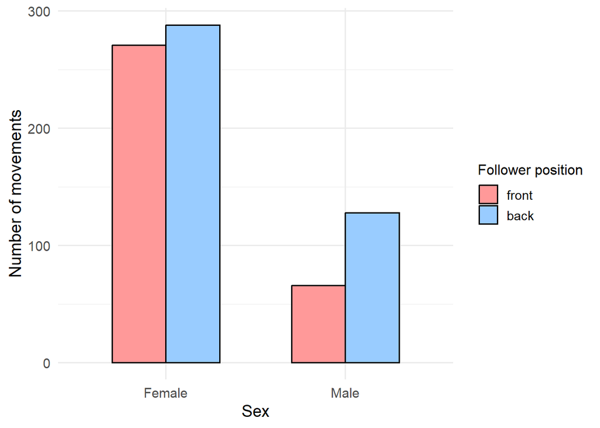

```r
# Crear un dataframe resumido por sexo y posición
df_bar <- df %>%
  filter(context == "Feeding") %>%  # filtrar solo Feeding
  group_by(sex) %>%
  summarise(
    front = sum(n_front),
    back = sum(n_back),
    total = sum(n_follower)  # total movimientos
  ) %>%
  tidyr::pivot_longer(cols = c(front, back), names_to = "position", values_to = "moves") %>%
  mutate(position = factor(position, levels = c("front", "back")))  # controlamos el orden


# Barplot vertical
ggplot(df_bar, aes(x = sex, y = moves, fill = position)) +
  geom_bar(stat = "identity",
           position = "dodge",  # ancho entre barras
           width = 0.6,  # ancho de cada barra
           color = "black") +  # borde negro fino

  scale_fill_manual(values = c("front" = "#FF9999", "back" = "#99CCFF"),
                    name = "Follower position") +
  scale_y_continuous(name = "Number of movements") +
  scale_x_discrete(name = "Sex", labels = c("F" = "Female", "M" = "Male")) +
  theme_minimal(base_size = 14) +
    theme(
      legend.title = element_text(size = 12),
      legend.text = element_text(size = 11),
      plot.title = element_text(size = 16, face = "bold", hjust = 0.5)
    )
```

### Second prediction with 2 models reproductive status in feeding context

- first, the number of times each individual moved toward feeding trees as leader and as follower per month was added as a two‐vector response variable and the fixed predictor was female reproductive state.

```r
run_model_leader_prop(df, response_type="leader_follower", predictor="repro_status", context_name="Feeding")
```

```
##
## Running models for context: Feeding and predictor: repro_status
## Data: dat
## Models:
## null1: cbind(n_leader, n_follower) ~ (1 | ID)
## model1: cbind(n_leader, n_follower) ~ repro_status + (1 | ID)
##        npar     AIC    BIC  logLik -2*log(L)  Chisq Df Pr(>Chisq)
## null1     2 103.424 106.48 -49.712    99.424
## model1    4  98.419 104.52 -45.209    90.419 9.0052  2    0.01108 *
## ---
## Signif. codes:  0 '***' 0.001 '**' 0.01 '*' 0.05 '.' 0.1 ' ' 1
```

```
## $model1
## Generalized linear mixed model fit by maximum likelihood (Laplace
##   Approximation) [glmerMod]
##  Family: binomial  ( logit )
## Formula: cbind(n_leader, n_follower) ~ repro_status + (1 | ID)
##    Data: dat
##
##       AIC       BIC    logLik -2*log(L)  df.resid
##      98.4     104.5     -45.2      90.4        30
##
## Scaled residuals:
##     Min      1Q  Median      3Q     Max
## -1.1737 -0.6681 -0.3980  0.2769  1.9666
##
## Random effects:
##  Groups Name        Variance Std.Dev.
##  ID     (Intercept) 0.2358   0.4856
## Number of obs: 34, groups:  ID, 17
##
## Fixed effects:
##                 Estimate Std. Error z value Pr(>|z|)
## (Intercept)      -3.5669     0.4589  -7.772 7.72e-15 ***
## repro_statusAFD   1.3598     0.6694   2.031  0.04221 *
## repro_statusAFL   1.5626     0.5145   3.037  0.00239 **
## ---
## Signif. codes:  0 '***' 0.001 '**' 0.01 '*' 0.05 '.' 0.1 ' ' 1
##
## Correlation of Fixed Effects:
##             (Intr) rp_AFD
## rpr_sttsAFD -0.636
## rpr_sttsAFL -0.861  0.568
```

Conclusion:

Reproductive status strongly influences leadership during feeding.

Both AFD and AFL individuals have higher odds of leading than the baseline group.

AFL individuals show the strongest effect.

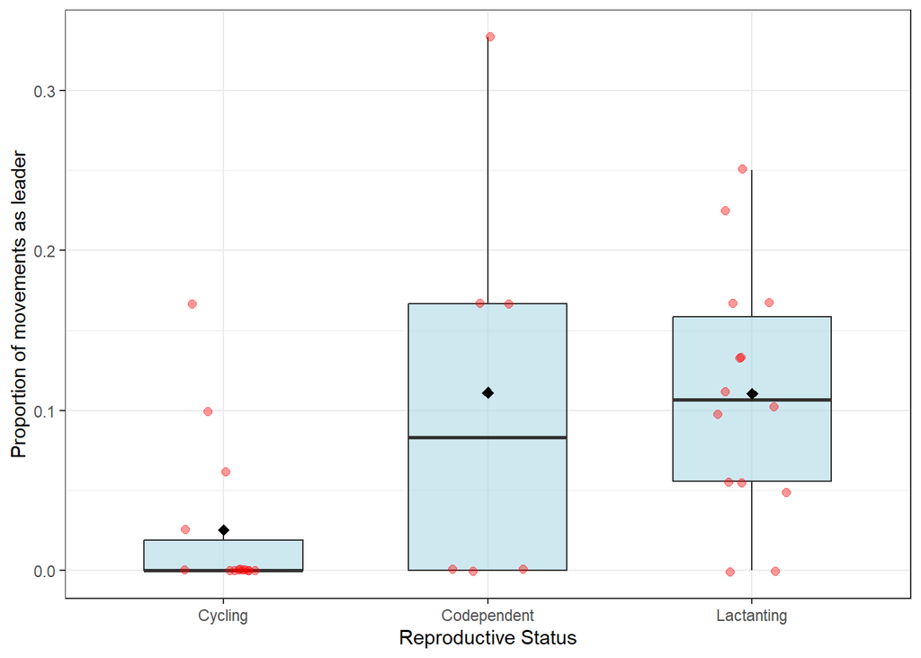

```r
# Filtramos solo el contexto Feeding
df_females <- subset(df, sex == "F") |>
  subset(context == "Feeding")


ggplot(df_females, aes(x = repro_status, y = prop_leader, fill = repro_status)) +
  geom_boxplot(width = 0.6, alpha = 0.6, outlier.shape = NA) +
  geom_jitter(width = 0.15, alpha = 0.4, color = "red", size = 2) +
  stat_summary(fun = mean, geom = "point", shape = 23, size = 2, fill = "black") +
  theme_bw() +
  labs(x = "Reproductive status", y = "Proportion of movements as leader") +
  scale_fill_manual(values = c("AFC" = "lightblue", "AFD" = "lightblue", "AFL" = "lightblue"))+
    scale_x_discrete(name = "Reproductive Status", labels = c("AFC" = "Cycling", "AFD" = "Codependent", "AFL" = "Lactanting")) +
  theme(legend.position = "none")
```

- second, mean individual monthly progression order index during movements toward feeding trees categorized as “front” or “back” was the dependent variable and female reproductive state was the fixed predictor.

```r
run_model_order_index(df, response_type="order_index", predictor="repro_status", context_name="Feeding")
```

```
##
## Running models for context: Feeding and predictor: repro_status
```

```
## Data: dat
## Models:
## null2: prop_front ~ (1 | ID)
## model2: prop_front ~ repro_status + (1 | ID)
##        npar     AIC     BIC logLik -2*log(L)  Chisq Df Pr(>Chisq)
## null2     3   2.666  7.2450  1.667    -3.334
## model2    5 -10.938 -3.3065 10.469   -20.938 17.604  2  0.0001504 ***
## ---
## Signif. codes:  0 '***' 0.001 '**' 0.01 '*' 0.05 '.' 0.1 ' ' 1
##
##   Simultaneous Tests for General Linear Hypotheses
##
## Multiple Comparisons of Means: Tukey Contrasts
##
##
## Fit: lmer(formula = prop_front ~ repro_status + (1 | ID), data = dat)
##
## Linear Hypotheses:
##                Estimate Std. Error z value Pr(>|z|)
## AFD - AFC == 0   0.5380     0.1146   4.693  < 0.001 ***
## AFL - AFC == 0   0.3125     0.0888   3.519  0.00122 **
## AFL - AFD == 0  -0.2256     0.1146  -1.968  0.11868
## ---
## Signif. codes:  0 '***' 0.001 '**' 0.01 '*' 0.05 '.' 0.1 ' ' 1
## (Adjusted p values reported -- single-step method)
```

```
## $model2
## Linear mixed model fit by REML ['lmerMod']
## Formula: prop_front ~ repro_status + (1 | ID)
##    Data: dat
##
## REML criterion at convergence: -10.4
##
## Scaled residuals:
##     Min      1Q  Median      3Q     Max
## -1.7025 -0.5369  0.0015  0.6155  1.6680
##
## Random effects:
##  Groups   Name        Variance Std.Dev.
##  ID       (Intercept) 0.01659  0.1288
##  Residual             0.02201  0.1483
## Number of obs: 34, groups:  ID, 17
##
## Fixed effects:
##                 Estimate Std. Error t value
## (Intercept)      0.25641    0.06279   4.084
## repro_statusAFD  0.53803    0.11464   4.693
## repro_statusAFL  0.31248    0.08880   3.519
##
## Correlation of Fixed Effects:
##             (Intr) rp_AFD
## rpr_sttsAFD -0.548
## rpr_sttsAFL -0.707  0.387
```

Conclusions:

Reproductive status strongly predicts front positioning during feeding.

AFD individuals are most likely at the front, AFL also more than AFC, while AFC females tend to stay behind.

Individual variation exists but is small compared to the effect of reproductive status.

AFL vs. AFD difference is not significant.

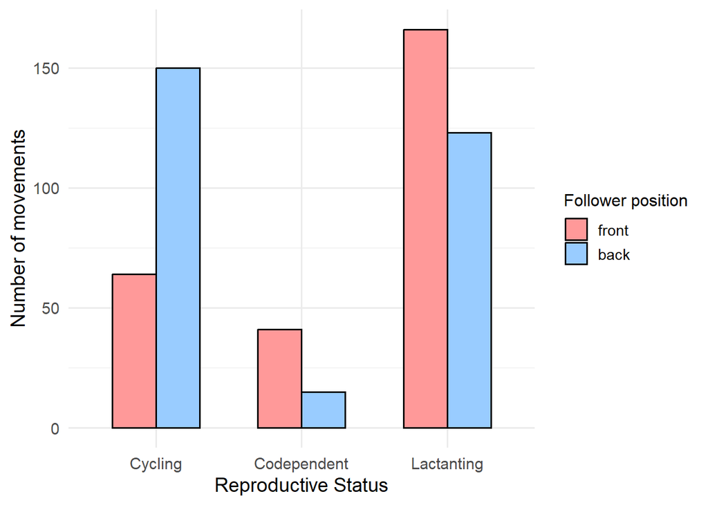

```r
# Crear un dataframe resumido por sexo y posición
df_bar <- df %>%
  filter(context == "Feeding" & sex == "F") %>%  # filtrar solo Feeding
  group_by(repro_status) %>%
  summarise(
    front = sum(n_front),
    back = sum(n_back),
    total = sum(n_follower)  # total movimientos
  ) %>%
  tidyr::pivot_longer(cols = c(front, back), names_to = "position", values_to = "moves") %>%
  mutate(position = factor(position, levels = c("front", "back")))  # controlamos el orden


# Barplot vertical
ggplot(df_bar, aes(x = repro_status, y = moves, fill = position)) +
  geom_bar(stat = "identity",
           position = "dodge",  # ancho entre barras
           width = 0.6,  # ancho de cada barra
           color = "black") +  # borde negro fino

  scale_fill_manual(values = c("front" = "#FF9999", "back" = "#99CCFF"),
                    name = "Follower position") +
  scale_y_continuous(name = "Number of movements") +
  scale_x_discrete(name = "Reproductive Status", labels = c("AFC" = "Cycling", "AFD" = "Codependent", "AFL" = "Lactanting")) +
  theme_minimal(base_size = 14) +
  theme(
    legend.title = element_text(size = 12),
    legend.text = element_text(size = 11),
    plot.title = element_text(size = 16, face = "bold", hjust = 0.5)
  )
```

In all models, subject identity was included as a random factor to account for the repeated sampling of individuals through time.

When the reproductive state had a significant effect in response variables, we ran post hoc Tukey pairwise comparisons. All analyses were performed with R 3.6.0 (R Core Team, 2019) using packages “car” 3.0‐3 (Fox, Weisberg, & Price, 2019), “lme4” 1.1‐21 (Bates, Maechler, Bolker, & Walker, 2019), and “multcomp” 1.4‐10 (Hothorn, Bretz, & Westfall, 2019).